# Proximity

2026-02-28 · Shammah Chancellor

If you’re not in the Bay Area, skip this one.

Also on [Substack](https://shablag.substack.com/p/proximity)

*If you’re not in the Bay Area, skip this one.*

**Booking:** twinettasimpkins.youcanbook.me

One of the best relationships I’ve had in the last five years started when someone came to clean my house.

Twinetta Simpkins has been cleaning my place since at least early 2023. I went through a few before I found her. In that time, she became a genuine friend. She’s warm, she’s reliable, she shows up; and when she’s there, she notices and fixes things you didn’t even know needed fixing—like my poor plants.

She’s a single mom raising a teenage son in Oakland. She also cares for an elderly client a couple days a week. She keeps her circle small and she’s loyal to the people in it.

The internet was supposed to solve loneliness. Instead it gave us thousands of digital connections and made the people in our actual physical orbit feel optional.

They’re not optional. The person who shows up at your address, who exists in your real space and not your feed, has a different weight. It either grows into something real or it doesn’t; but it happens in a way that leaves a mark.

That’s what proximity does: it creates conditions for discovery that digital networks don’t.

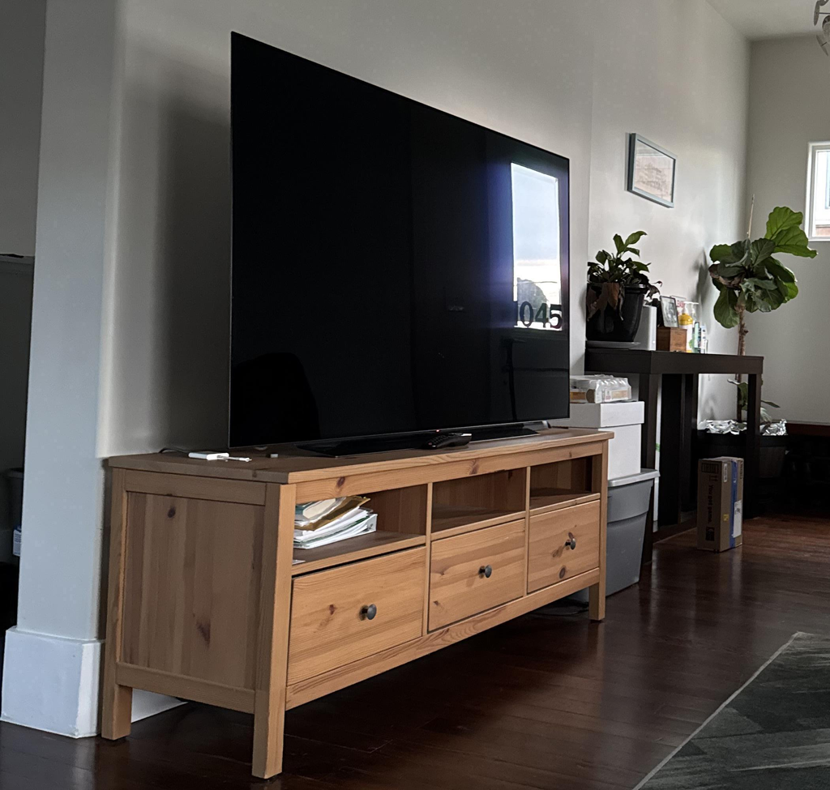

Living room after Twinetta

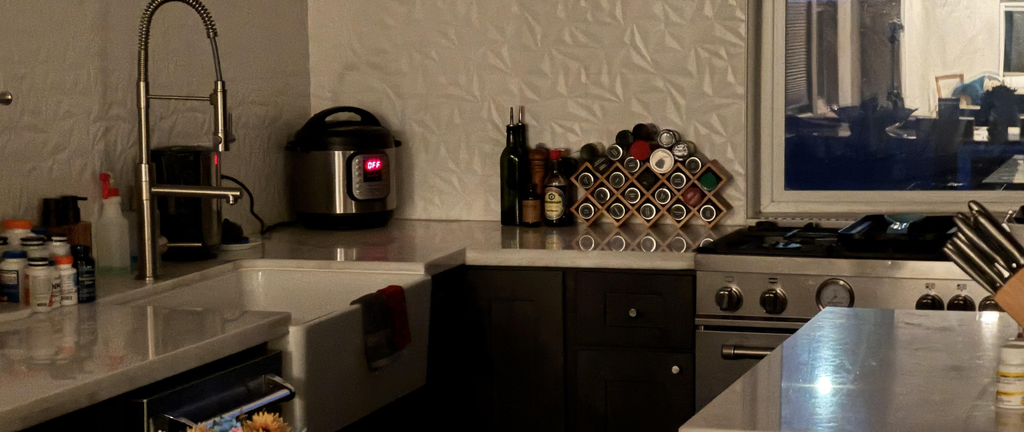

Kitchen after Twinetta

She’s taking new clients in the Bay Area. She handles large homes. She’s meticulous, warm, and dependable. If you know someone in the Bay who needs a housekeeper, send them this.

$100/hour. A full home typically takes a day. Include your address when booking. Not available Wednesdays and Fridays; she has a regular client those days.

I just want her to have more work.

**Booking:** twinettasimpkins.youcanbook.me

Read and subscribe on [Substack](https://shablag.substack.com/p/proximity)